# Technical Appendix: Welfare State and Risk Perceptions, Part II

Nate Breznau

5/18/2020

This is an analysis of public concern about the COVID-19 pandemic and various socioeconomic factors at the country-level.

You will find all of the data files plus the original R code on the Open Science Framework: https://osf.io/muhdz/

```r
rm(list = ls(all = TRUE))

pacman::p_load("dplyr","wbstats","readstata13","countrycode","car","ggplot2","xlsx","jtools","sjPlot","sjmisc","sjlabelled","tidyverse","corrplot","psych","lavaan","kable","kableExtra","ggrepel","stringi", "ragg")

# function to keep complete cases
completeFun <- function(data, desiredCols) {
  completeVec <- complete.cases(data[, desiredCols])
  return(data[completeVec, ])
}
```

## 1. Data Prep

### 1.1 COVIDiSTRESS Project

The csv files were cleaned by Nate Breznau. Cleaning code “cis_clean.Rmd” here: https://osf.io/au3jy/

A comparative survey of psychological stress and pandemic attitudes. Not representative.

Original English question wording:

Concern about consequences of the coronavirus (1)…for yourself (2)…for your family (3)…for your close friends (4)…for your country (5)…for other countries across the globe

```r
load(file = here::here("data/cis.Rdata"), .GlobalEnv)

# Demographic recodes
cis <- cis %>%
  mutate(date = as.Date(StartDate),
         female = as.numeric(Dem_gender) - 1,
         age = as.numeric(Dem_age),
         educ_years = as.numeric(car::recode(Dem_edu, recode = "7 = 6;6 = 9;5 = 12;4 = 14;3 = 16; 2 = 20")),
         educ_uni = as.numeric(car::recode(Dem_edu, recode = "4:7=0;1=0;2:3=1"))) %>%
  rowwise() %>%
         mutate(concern_self = mean(c(Corona_concerns_1,Corona_concerns_2,Corona_concerns_3), na.rm=T),
         concern_society = mean(c(Corona_concerns_4,Corona_concerns_5), na.rm=T),
         period = ifelse(date < as.Date('2020-03-31'), 1, ifelse(date < as.Date('2020-04-01'), 2, ifelse(date < as.Date('2020-04-04'), 3, ifelse(date < as.Date('2020-04-07'), 4, ifelse(date < as.Date('2020-04-12'), 5, ifelse(date < as.Date('2020-04-19'), 6, ifelse(date < as.Date('2020-05-05'), 7, 8))))))))

cis <- cis %>%
  group_by(period,cow) %>%
  mutate(cases_p_c = length(na.omit(concern_self))) %>%
  ungroup()

cis <- cis %>%
  group_by(cow) %>%
  mutate(cases_p_c = min(cases_p_c, na.rm = T)) %>%
  ungroup()

# S.Sudan and Panama have very few non-missing cases, plus some countries are NA. Remove.
cis <- subset(cis, !is.na(cow) & cow!=95)

cis_na <- cis %>%
  mutate(cases_p_c = ifelse(cases_p_c < 20, NA, cases_p_c))

cis_na <- completeFun(cis_na, "cases_p_c")

cisC <- subset(cis, date < as.Date("2020-05-01"))
cisC <- subset(cisC, cases > 20)
# Make list of using countries

use_countries <- as.list(c(2, 20, 55, 70, 90, 92, 94, 100, 130, 135, 140, 155, 160, 200, 205, 210, 211, 212, 220, 225, 230, 235, 255, 290, 305, 310, 316, 317, 325, 338, 339, 350, 352, 355, 360, 365, 366, 367, 368, 369, 372, 375, 380, 385, 390, 395, 560, 600, 615, 640, 651, 666, 696, 700, 703, 710, 713, 732, 740, 750, 770, 771, 816, 820, 830, 835, 840, 850, 900, 920))

use_countriesa <- as.list(c(2, 20, 55, 70, 90, 92, 94, 100, 130, 135, 140, 155, 160, 200, 205, 210, 211, 212, 220, 225, 230, 235, 255, 290, 305, 310, 316, 317, 325, 338, 339, 343, 344, 346, 349, 350, 352, 355, 360, 365, 366, 367, 368, 369, 372, 375, 380, 385, 390, 395, 560, 600, 615, 640, 651, 666, 696, 700, 703, 710, 713, 732, 740, 750, 770, 771, 816, 820, 830, 835, 840, 850, 900, 920))


rm(cisC)

table(cis$period)
```

```
##
##     1     2     3     4     5     6     7     8
## 14722 16182 31279 22702 15064 12672  5067  6490
```

### Visualize Concern by Period

There appear to be global period effects as almost all countries decline in concern after April. However, as this chart makes clear, there are not enough cases per period to do cross-national analysis. Only 14 countries have more than 20 cases per period through mid-June.

#### Figure 2 (Appendix Only). Countries with Consistent Data Throughout the Survey

```r
cis_na$group <- paste(cis_na$period,cis_na$iso, sep = "_")
cis1_na <- cis_na %>%
  group_by(group) %>%
  summarise_at(vars(concern_self, concern_society), funs(mean(., na.rm=TRUE)))
```

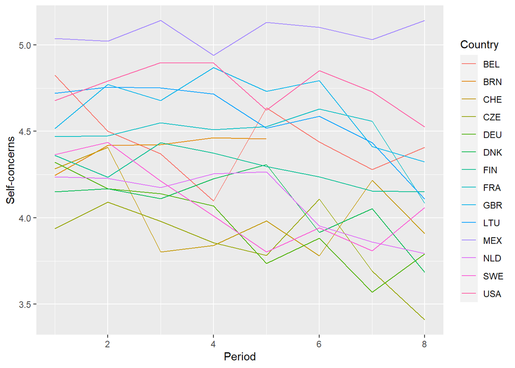

```r
cis1_na <- cis1_na %>%
  mutate(Country = stri_sub(group,-3,-1),
         period = as.numeric(stri_sub(group,1,1)))

#need to create number of cases per group-period variable and reduce data here

ggplot(data=cis1_na, aes(x=period , y=concern_self, group=Country, color=Country)) +
    geom_line() +
  labs(x= "Period", y = "Self-concerns")
```

### Measurement Model

#### CFA 1 v 2 latents

```r
concern_m1 <- ' all  =~ Corona_concerns_1 + Corona_concerns_2 + Corona_concerns_3 + Corona_concerns_4 + Corona_concerns_5'

concern_m2 <- ' self  =~ Corona_concerns_1 + Corona_concerns_2 + Corona_concerns_3
                country =~ Corona_concerns_4 + Corona_concerns_5'

concern_m3 <- ' self  =~ Corona_concerns_1 + f*Corona_concerns_2 + c(a,a,a,a,a,a,a,a,a,a,a,a,a,a,a,b,a,a,a,a,a,a,a,c,a,a,a,a,a,a,a,a,a,a,a,a,a,a,a,a,a,a,a,a,a,d,a)*Corona_concerns_3
                country =~ Corona_concerns_4 + g*Corona_concerns_5'

# Use countries with more cases for this test

cis_mgcfa <- subset(cis, date < as.Date('2020-05-01') & cases > 100)

fit1 <- cfa(concern_m1, data=cis_mgcfa)
fit2 <- cfa(concern_m2, data=cis_mgcfa)
f1 <- summary(fit1, fit.measures=T)
f2 <- summary(fit2, fit.measures=T)
```

#### Multigroup Invariance Test

```r
fit3 <- cfa(concern_m3, data=cis_mgcfa, group = "cname")
f3 <- summary(fit3, fit.measures=T)
```

```r
cfa <- list(f1[["FIT"]][["cfi"]],f1[["FIT"]][["tli"]],f1[["FIT"]][["rmsea"]],f2[["FIT"]][["cfi"]],f2[["FIT"]][["tli"]],f2[["FIT"]][["rmsea"]],f3[["FIT"]][["cfi"]],f3[["FIT"]][["tli"]],f3[["FIT"]][["rmsea"]])

cfa <- round(as.numeric(cfa), 3)

names(cfa) <- c("CFI_1","TLI_1","RMSEA_1","CFI_2","TLI_2","RMSEA_2","CFI_3","TLI_3","RMSEA_3")


rm(cis_mgcfa)

print(cfa)
```

```
##   CFI_1   TLI_1 RMSEA_1   CFI_2   TLI_2 RMSEA_2   CFI_3   TLI_3 RMSEA_3
##   0.805   0.609   0.293   0.998   0.994   0.037   0.981   0.973   0.077
```

### Data Sources

#### Johns Hopkins Covid-19 Tracker

A multi-source project for compiling global confirmed cases, deaths and recoveries.

Available at: https://github.com/CSSEGISandData/COVID-19/tree/master/csse_covid_19_data

These files were downloaded. They have to be used as is, otherwise the rows and columns change. Otherwise the date range has to be adjusted by the number of columns in the code below.

```r
confirmed <- read.csv(here::here("data/time_series_covid19_confirmed_global.csv"), header = F)
deaths <- read.csv(here::here("data/time_series_covid19_deaths_global.csv"), header = F)


confirmed[1,1] <- "Province"
confirmed[1,2] <- "Country"
deaths[1,1] <- "Province"
deaths[1,2] <- "Country"

cnames <- as.list(confirmed[1,1:130])
cnamesd <- as.list(deaths[1,1:155])

colnames(confirmed) <- cnames
colnames(deaths) <- cnamesd

confirmed[,5:130] <- sapply(confirmed[5:130],as.numeric)
deaths[,5:155] <- sapply(deaths[5:155],as.numeric)

# Canada, Australia and China are by province, not a sum

cca <- subset(confirmed, Country=="Australia", select = -c(Province,Country,Lat,Long))
ccca <- subset(confirmed, Country=="Canada", select = -c(Province,Country,Lat,Long))
ccch <- subset(confirmed, Country=="China", select = -c(Province,Country,Lat,Long))
ccad <- subset(deaths, Country=="Australia", select = -c(Province,Country,Lat,Long))
cccad <- subset(deaths, Country=="Canada", select = -c(Province,Country,Lat,Long))
ccchd <- subset(deaths, Country=="China", select = -c(Province,Country,Lat,Long))


a <- as.data.frame(colSums(cca, na.rm = T))
b <- as.data.frame(colSums(ccca, na.rm = T))
c <- as.data.frame(colSums(ccch, na.rm = T))
ad <- as.data.frame(colSums(ccad, na.rm = T))
bd <- as.data.frame(colSums(cccad, na.rm = T))
cd <- as.data.frame(colSums(ccchd, na.rm = T))

aa <- data.frame("All","Australia",0,0,t(a))
bb <- data.frame("All","Canada",0,0,t(b))
cc <- data.frame("All","China",0,0,t(c))
aaa <- data.frame("All","Australia",0,0,t(ad))
bbb <- data.frame("All","Canada",0,0,t(bd))
ccc <- data.frame("All","China",0,0,t(cd))

colnames(aa) <- cnames
colnames(bb) <- cnames
colnames(cc) <- cnames
colnames(aaa) <- cnamesd
colnames(bbb) <- cnamesd
colnames(ccc) <- cnamesd

# add the three missing countries
confirmed <- rbind(confirmed,aa,bb,cc)
deaths <- rbind(deaths,aaa,bbb,ccc)

# remove province-level data
confirmed <- subset(confirmed, Province=="" | Province=="All")
deaths <- subset(deaths, Province=="" | Province=="All")

rm(a,b,c,aa,bb,cc,ad,bd,cd,aaa,bbb,ccc,cca,ccca,ccch,ccad,cccad,ccchd)

confirmed <- subset(confirmed, select = -c(Province,Lat,Long))
deaths <- subset(deaths, select = -c(Province,Lat,Long))

# Final data for merging, wide
hopkins <- left_join(confirmed, deaths, by = "Country")
hopkins$cow <- countrycode(hopkins$Country, "country.name", "cown")

colnames(confirmed) <- paste0("conf",colnames(confirmed))
colnames(confirmed)[1] <- "Country"

colnames(deaths) <- paste0("dead",colnames(deaths))
colnames(deaths)[1] <- "Country"


confirmed_long <- reshape(confirmed, idvar = "Country", direction = "long", v.names = "conf", varying = 2:127)

deaths_long <- reshape(deaths, idvar = "Country", direction = "long", v.names = "dead", varying = 2:151)

datel <- seq.Date(as.Date("2020-1-22"),as.Date("2020-5-26"), by = "days")
datea <- seq.int(1,126)
dateld <- seq.Date(as.Date("2020-1-22"),as.Date("2020-6-20"), by = "days")
datead <- seq.int(1,151)


datem <- data.frame(time = datea, date = datel)
datemd <- data.frame(time = datead, date = dateld)
datem$date <- as.Date(datem$date)
datemd$date <- as.Date(datemd$date)

deaths_long <- left_join(deaths_long,datemd)
confirmed_long <- left_join(confirmed_long,datem)

deaths_long$cow <- countrycode(deaths_long$Country, "country.name", "cown")
confirmed_long$cow <- countrycode(confirmed_long$Country, "country.name", "cown")

# lagged versions, 5-days

# sort first
deaths_long <- deaths_long[order(deaths_long$cow, deaths_long$date),]
confirmed_long <- confirmed_long[order(confirmed_long$cow, confirmed_long$date),]

deaths_long <- deaths_long %>%
  mutate(dead_l5 = lag(dead, n = 5L),
         dead_lead = lead(dead, n = 18L), # create 2.5 week lead (18 days)
         dead_s = ifelse(dead > 0, 1, 0),# first death ID
         dead_s1l = lag(dead_s, 1L),
         dead_dif = dead_s - dead_s1l,
         dead_dif = ifelse(cow == 710 & date == as.Date("2020-01-22"), 1, dead_dif))

# first death date

deaths_long <- deaths_long %>%
  group_by(cow) %>%
  mutate(dead_1st = dplyr::if_else(dead_dif == 1, as.Date(date), as.Date("2020-06-02")),
         dead_1st_date = min(dead_1st, na.rm=T)) %>%
  ungroup()

confirmed_long <- confirmed_long %>%
  mutate(conf_l5 = lag(conf, n = 5L),
         conf_l10 = lag(conf, n = 10L))


deaths_long <- select(deaths_long, dead, dead_l5, dead_lead, dead_1st_date, date, cow)
confirmed_long <- select(confirmed_long, conf, conf_l5, conf_l10, date, cow)

# l5 variable comes from the wrong series prior to 1-27
deaths_long$dead_l5 <- ifelse(deaths_long$date < as.Date("2020-01-27"), NA, deaths_long$dead_l5)

confirmed_long$conf_l5 <- ifelse(confirmed_long$date < as.Date("2020-01-27"), NA, confirmed_long$conf_l5)
confirmed_long$conf_l10 <- ifelse(confirmed_long$date < as.Date("2020-02-01"), NA, confirmed_long$conf_l10)

# increasing or decreasing rate past week, numbers are so different that I make a trichotomy: < 1 = -1, 0-1 = 0 and > 1 = 1
confirmed_long$conf_delta <- (confirmed_long$conf - confirmed_long$conf_l5) - (confirmed_long$conf_l5 - confirmed_long$conf_l10)

confirmed_long$conf_delta <- ifelse(confirmed_long$conf_delta < 0, -1, ifelse(confirmed_long < 1.01, 0, 1))



# Merge cases and deaths per date of survey per respondent


# Find the moment with the curve 'flattens'

deaths_long <- deaths_long %>%
  mutate(dead_lead12 = lag(dead_lead, 12L),
         dead_lead11 = lag(dead_lead, 11L),
         dead_lead10 = lag(dead_lead, 10L),
         dead_lead9 = lag(dead_lead, 9L),
         dead_lead8 = lag(dead_lead, 8L),
         dead_lead5 = lag(dead_lead, 5L),
         dead_lead4 = lag(dead_lead, 4L),
         dead_lead3 = lag(dead_lead, 3L),
         dead_lead2 = lag(dead_lead, 2L),
         dead_lead1 = lag(dead_lead, 1L),
         dead_lead_past12 = (dead_lead12 + dead_lead11 + dead_lead10 + dead_lead9 + dead_lead8)/5,
         dead_lead_past5 = (dead_lead5 + dead_lead4 + dead_lead3 + dead_lead2 + dead_lead1)/5,
         dead_lead_wkchg = dead_lead_past12 - dead_lead_past5)

# find the minimum point of weekly change, this is the height of the curve

deaths_long <- deaths_long %>%
  group_by(cow) %>%
  mutate(curve_maxd = min(dead_lead_wkchg, na.rm=T),
         curve_maxs = dplyr::if_else(curve_maxd == dead_lead_wkchg, as.Date(date), as.Date("2020-6-2")),
         curve_max = min(curve_maxs, na.rm=T)) %>%
  ungroup()

deaths_long <- subset(deaths_long, select = -c(curve_maxd, curve_maxs))


rm(cis_na)

cis$date = as.Date(cis$EndDate)
cis <- left_join(cis,deaths_long, by = c("cow","date"))
cis <- left_join(cis,confirmed_long, by = c("cow","date"))

# cis_dk <- subset(cis, cow == 390)
```

#### ILO - GEIP

ILO. 2014. “Global Programme Employment Injury Insurance and Protection | GEIP Data.” https://www.ilo.org/wcmsp5/groups/public/---ed_emp/---emp_ent/documents/publication/wcms_573083.pdf

#### Maddison Data - GDP

(see book chapter for details)

```r
gdpm <- read.csv(here::here("data/mpd2018.csv"), header=T, stringsAsFactors = F)

gdpm <- subset(gdpm, year > 2013)
gdpm <- select(gdpm, country, cgdppc, pop)
gdpc <- aggregate(gdpm, by = list(gdpm$country), FUN = mean)
gdpc$cow <- countrycode(gdpc$Group.1, "country.name", "cown")
gdpc <- gdpc %>%
  mutate(gdp = round(cgdppc,0),
         pop = round(pop,0))
gdpc <- select(gdpc, cow, gdp, pop)

gdpc <- completeFun(gdpc, "cow")
```

#### ILO - Social Spending

Public Social Expenditure as a % of GDP (Table .16) https://www.social-protection.org/gimi/gess/ShowWiki.action?id=594#tabs-3

```r
socp <- read.xlsx(here::here("data/54614.xlsx"), startrow = 8, sheetName = "B.16 Data (Print)")

socp <- completeFun(socp, "NA..1")

socp <- select(socp, NA..1, NA..18, NA..19, NA..20)

colnames(socp) <- c("country","soc_spend","year","source")

socp$country <- as.character(socp$country)
socp$soc_spend <- as.numeric(as.character(socp$soc_spend))

socp$cow <- countrycode(socp$country, "country.name","cown")

socp <- completeFun(socp, "soc_spend")
```

#### Policy Responses

##### Stay at home restriction timing

Mandatory = a code of 2 or 3

Policy Responses to the Coronavirus Pandemic, by Hannah Ritchie, Max Roser, Esteban Ortiz-Ospina and Joe Hasell https://ourworldindata.org/policy-responses-covid (downloaded June 19th, reformated date column to yyyy-mm-dd)

```r
presp <- read.csv(here::here("data/stay-at-home-covid.csv"), header = T)
colnames(presp) <- c("country","iso","date","policy")
presp <- presp %>%
  mutate(date = as.Date(date),
         cow = countrycode(country, "country.name","cown"),
         stay_home = ifelse(policy == 2 | policy == 3, 1, 0),
         stay_home_l1 = lag(stay_home, 1L),
         stay_dif = stay_home - stay_home_l1)

# first instance of mandatory stay at home order

presp <- presp %>%
  group_by(cow) %>%
  mutate(stay_home_1st = dplyr::if_else(stay_dif == 1, as.Date(date), as.Date("2020-06-02")),
         stay_home_day = min(stay_home_1st, na.rm=T)) %>%
  ungroup()

# US had no systematic stay home order (only some states)

presp$stay_home_day <- dplyr::if_else(presp$cow == 2, as.Date("2020-06-02"), presp$stay_home_day)

presp$days_since_stayhome <- as.Date("2020-06-02") - presp$stay_home_day

presp <- select(presp, cow, days_since_stayhome, stay_home_day)
presp <- aggregate(presp, by = list(presp$cow), FUN = min)
```

##### School Closures

https://www.bsg.ox.ac.uk/research/research-projects/coronavirus-government-response-tracker#data

Removed notes from bottom of csv by hand OxCGRT_timeseries_all.csv School closures: 0 - No measures 1 - recommend closing 2 - Require closing (only some levels or categories, eg just high school, or just public schools) 3 - Require closing all levels No data - blank

The data for the US are false. Not all states closed schools. But as I recoded the mandatory stay at home variable to indicate that the federal government never gave mandatory stay home orders, it is OK to use this date and then take the midpoint (stay home and school closures) as the government treatment variable https://www.edweek.org/ew/section/multimedia/map-coronavirus-and-school-closures.html

Japan closed schools Feb 27th https://www.bbc.com/news/world-asia-51663182

```r
presps <- read.csv(here::here("data/OxCGRT_timeseries_all.csv"), header = F)
colnames(presps) <- c("Country","iso", as.character(presps[1,3:156]))
presps <- presps[-c(1),-c(2)]
presps_long <- reshape(presps, idvar = "Country", direction = "long", v.names = "sch", varying = 2:155)

das <- seq.Date(as.Date("2020-1-1"),as.Date("2020-6-2"), by = "days")
dasd <- seq.int(1,154)


dasf <- data.frame(time = dasd, date = das)

presps_long <- left_join(presps_long,dasf, by = "time")
presps_long$cow <- countrycode(presps_long$Country, "country.name", "cown")
presps_long <- select(presps_long, cow, sch, date)

# sort
presps_long <- presps_long[order(presps_long$cow, presps_long$date),]

presps_long <- presps_long %>%
  mutate(schs = ifelse(sch > 1, 1, 0),
         schsl = lag(schs, 1L),
         sch_dif =  schs - schsl)

presps_long <- presps_long %>%
  group_by(cow) %>%
  mutate(sch_datel = dplyr::if_else(sch_dif == 1, as.Date(date), as.Date("2020-6-2")),
         sch_date = min(sch_datel, na.rm=T)) %>%
  ungroup()

presps_long <- select(presps_long, cow, date, sch_date)
presps_long <- aggregate(presps_long, by = list(presps_long$cow), FUN = min)
presps_long$sch_date <- dplyr::if_else(presps_long$cow == 740, as.Date("2020-2-27"), as.Date(presps_long$sch_date))
```

### Figure 1. Outbreak Severity by Country

As testing rates vary dramatically by country, I take the number of deaths with a 2.5 week lead as a better indicator of the severity of the outbreak by country. Those who died were inevitably sick or showing symptoms 18 days prior.

```r
# this means the series ends at 06-01

deaths_long <- subset(deaths_long, date < as.Date("2020-06-02"))

# keep two extra days for plotting empty space

deaths_long$dead_lead <- ifelse(deaths_long$date > as.Date("2020-05-31"), NA, deaths_long$dead_lead)

# Using countries
deaths_longC <- subset(deaths_long, cow %in% use_countriesa)


# add Country name
deaths_longC$Country <- countrycode(deaths_longC$cow, "cown", "iso3c")
deaths_longC$Country <- ifelse(deaths_longC$cow ==  347, "KOS", deaths_longC$Country)




# log deaths
deaths_longC$dead_lead_log <- ifelse(deaths_longC$dead_lead > 3,log(deaths_longC$dead_lead),1)

# squared log deaths to accentuate differences
deaths_longC$dead_lead_log <- deaths_longC$dead_lead_log*deaths_longC$dead_lead_log

# create a label map so they do not overlap
deaths_longCL <- subset(deaths_longC, date == as.Date("2020-05-31"))
deaths_longCL <- deaths_longCL %>%
  mutate(date = ifelse(Country == "DEU" | Country == "RUS" | Country == "TUR" | Country == "ECU" | Country == "COL" | Country == "ZAF" | Country == "PRT" | Country == "BGD" | Country == "CHE" | Country == "UKR" | Country == "JPN" | Country == "DNK" | Country == "AFG" | Country == "CZE" | Country == "ISR" | Country == "KOR" | Country == "MAR" | Country == "GRC" | Country == "LUX" | Country == "HRV" | Country == "LTU" | Country == "ALB" | Country == "KGZ" | Country == "SVK" | Country == "NZL" | Country == "GEO" | Country == "ISL" | Country == "VNM" | Country == "TWN", "2020-06-06", "2020-06-01"),
         dead_lead_log = ifelse(Country == "CHE", 59.1, dead_lead_log),
         dead_lead_log = ifelse(Country == "DNK", 41.8, dead_lead_log),
         dead_lead_log = ifelse(Country == "UKR", 48.8, dead_lead_log),
         dead_lead_log = ifelse(Country == "CZE", 34.5, dead_lead_log),
         dead_lead_log = ifelse(Country == "KOR", 30.6, dead_lead_log),
         dead_lead_log = ifelse(Country == "MYS", 24.2, dead_lead_log),
         dead_lead_log = ifelse(Country == "AUS", 21.8, dead_lead_log),
         dead_lead_log = ifelse(Country == "LUX", 23.8, dead_lead_log),
         dead_lead_log = ifelse(Country == "FIN", 34.5, dead_lead_log),
         dead_lead_log = ifelse(Country == "KOS", 14, dead_lead_log),
         dead_lead_log = ifelse(Country == "ALB", 14.5, dead_lead_log),
         dead_lead_log = ifelse(Country == "LVA", 12.5, dead_lead_log),
         dead_lead_log = ifelse(Country == "GRC", 26.8, dead_lead_log),
         dead_lead_log = ifelse(Country == "KGZ", 12.5, dead_lead_log),
         dead_lead_log = ifelse(Country == "NZL", 9, dead_lead_log),
         dead_lead_log = ifelse(Country == "SVK", 10.5, dead_lead_log),
         dead_lead_log = ifelse(Country == "MEX", 99, dead_lead_log),
         dead_lead_log = ifelse(Country == "ESP", 103.8, dead_lead_log),
         dead_lead_log = ifelse(Country == "CRI", 7.35, dead_lead_log),
         dead_lead_log = ifelse(Country == "SLV", 5.78, dead_lead_log),
         dead_lead_log = ifelse(Country == "BRN", 2.6, dead_lead_log),
         dead_lead_log = ifelse(Country == "TWN", 3, dead_lead_log),
         dead_lead_log = ifelse(Country == "MLT", 4.16, dead_lead_log),
         dead_lead_log = ifelse(Country == "SWE", 73.2, dead_lead_log),
         dead_lead_log = ifelse(Country == "ZAF", 55.5, dead_lead_log),
          dead_lead_log = ifelse(Country == "ROU", 53.4, dead_lead_log),
         dead_lead_log = ifelse(Country == "ISL", 5.15, dead_lead_log),
         dead_lead_log = ifelse(Country == "CYP", 8.95, dead_lead_log),
         dead_lead_log = ifelse(Country == "SVK", 10.8, dead_lead_log))

# Using countries (study two)
deaths_longCa <- deaths_longC
deaths_longCLa <- deaths_longCL

# Using countries (study one)
deaths_longC <- subset(deaths_longC, Country!= "MKD" & Country!= "BIH" & Country!= "HRV" & Country!="SVN")
deaths_longCL <- subset(deaths_longCL, Country!= "MKD" & Country!= "BIH" & Country!= "HRV" & Country!="SVN")


agg_png(file = here::here("results/Fig1.png"), width = 1200, height = 1020,  res = 144)
ggplot(data=deaths_longC, aes(x=date , y=dead_lead_log, group=Country, color=Country)) +
    geom_line() +
  labs(x= "", y = "Outbreak Severity (log deaths, 18 day lead)") +
  geom_segment(aes(x = as.Date("2020-03-27"), y = 1, xend = as.Date("2020-03-27"), yend = 135), linetype = "dashed", color = "black", size = 0.8) +
  geom_segment(aes(x = as.Date("2020-04-30"), y = 1, xend = as.Date("2020-04-30"), yend = 135), linetype = "dashed", color = "black", size = 0.8) +
  annotate("text", x= as.Date("2020-01-21"), y= 5,
           label="5", size=4.5, color = "gray20") +
  annotate("text", x= as.Date("2020-01-21"), y= 30,
           label="250", size=4.5, color = "gray20") +
  annotate("text", x= as.Date("2020-01-21"), y= 55,
           label="2k", size=4.5, color = "gray20") +
  annotate("text", x= as.Date("2020-01-21"), y= 80,
           label="8k", size=4.5, color = "gray20") +
  annotate("text", x= as.Date("2020-01-21"), y= 105,
           label="30k", size=4.5, color = "gray20") +
  annotate("text", x= as.Date("2020-01-21"), y= 130,
           label="120k", size=4.5, color = "gray20") +
  annotate("text", x= as.Date("2020-04-13"), y=137, label="survey time-frame", size = 4, color="black") +
  scale_x_date(date_breaks = "2 weeks" , date_labels = "%d-%b") +
  geom_text(data = deaths_longCL, aes(label = Country, colour = Country, x = as.Date(date), y = dead_lead_log, hjust = -.1), size = 2.62) +
  theme(legend.position = "none",
        panel.background = element_blank(),
        axis.text.y = element_blank(),
        axis.ticks = element_blank(),
        axis.title.y = element_text(size=14, vjust=-0.5),
        axis.text.x = element_text(vjust=1, hjust=0.35, color = "gray20", size = 12),
        plot.margin = margin(0, 1, 0, 0, "cm"))
dev.off()
```

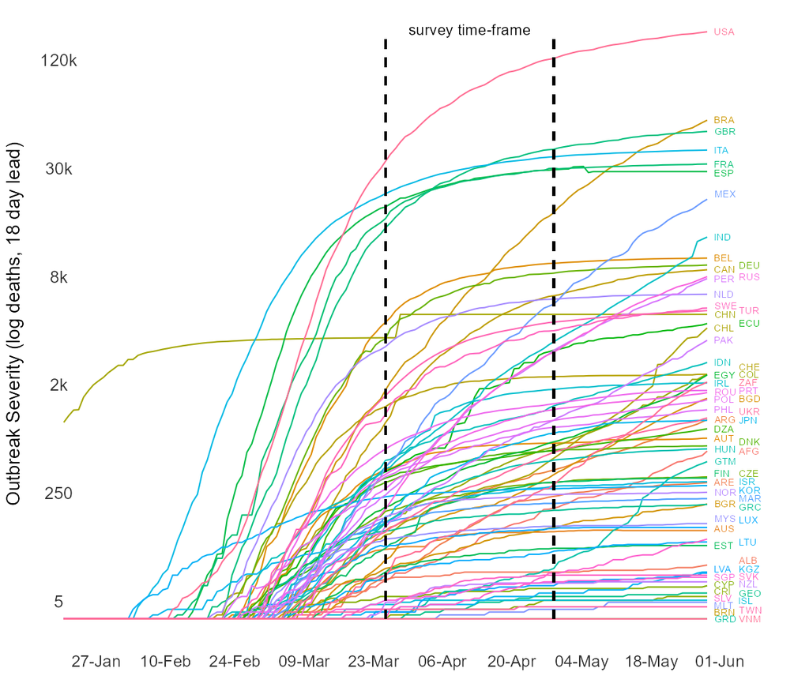

```r
knitr::include_graphics(here::here("results/Fig1.png"))
```

```r
# this is a version for study 2

# labels need adjustment
deaths_longCLa <- deaths_longCLa %>%
  mutate(dead_lead_log = ifelse(Country == "AUS", 20.2, dead_lead_log),
         dead_lead_log = ifelse(Country == "BIH", 25.3, dead_lead_log),
         dead_lead_log = ifelse(Country == "BGR", 26.9, dead_lead_log),
         dead_lead_log = ifelse(Country == "MKD", 28.6, dead_lead_log),
         dead_lead_log = ifelse(Country == "MYS", 23.6, dead_lead_log))


fig1_2 <- ggplot(data=deaths_longCa, aes(x=date , y=dead_lead_log, group=Country, color=Country)) +
    geom_line() +
  labs(x= "", y = "Outbreak Severity (18 day lead of COVID-19 deaths)") +
  geom_segment(aes(x = as.Date("2020-03-27"), y = 1, xend = as.Date("2020-03-27"), yend = 135), linetype = "dashed", color = "black", size = 0.8) +
  geom_segment(aes(x = as.Date("2020-04-30"), y = 1, xend = as.Date("2020-04-30"), yend = 135), linetype = "dashed", color = "black", size = 0.8) +
  annotate("text", x= as.Date("2020-01-21"), y= 5,
           label="5", size=4.5, color = "gray20") +
  annotate("text", x= as.Date("2020-01-21"), y= 30,
           label="250", size=4.5, color = "gray20") +
  annotate("text", x= as.Date("2020-01-21"), y= 55,
           label="2k", size=4.5, color = "gray20") +
  annotate("text", x= as.Date("2020-01-21"), y= 80,
           label="8k", size=4.5, color = "gray20") +
  annotate("text", x= as.Date("2020-01-21"), y= 105,
           label="30k", size=4.5, color = "gray20") +
  annotate("text", x= as.Date("2020-01-21"), y= 130,
           label="120k", size=4.5, color = "gray20") +
  annotate("text", x= as.Date("2020-04-13"), y=137, label="survey time-frame", size = 4, color="black") +
  scale_x_date(date_breaks = "2 weeks" , date_labels = "%d-%b") +
  geom_text(data = deaths_longCLa, aes(label = Country, colour = Country, x = as.Date(date), y = dead_lead_log, hjust = -.1), size = 2.62) +
  theme(legend.position = "none",
        panel.background = element_blank(),
        axis.text.y = element_blank(),
        axis.ticks = element_blank(),
        axis.title.y = element_text(size=14, vjust=-0.5),
        axis.text.x = element_text(vjust=1, hjust=0.35, color = "gray20", size = 12),
        plot.margin = margin(0, 1, 0, 0, "cm"))

# log conversion
# 30 = 250
# 55 = 2,000
# 80 = 8,000
# 105 = 28,000
# 130 = 120,000
```

### Merge Data

```r
# The wider the date range the greater the chance of introducing global/regional period effects. Reduce range, but maximize country sample.

# cis_b is to remain at individual level
cis_b <- subset(cis, date < as.Date('2020-05-01'))

cis_a <- aggregate(cis_b, by=list(cis_b$cow),
  FUN=mean, na.rm=T)

# added 16-Aug-20, calculate SE for study_two
cis_asd <- aggregate(cis_b, by=list(cis_b$cow),
  FUN=sd, na.rm=T)
cis_asd <- select(cis_asd, Group.1, concern_self)
colnames(cis_asd) <- c("cow", "concern_self_sd")

cis_a <- left_join(cis_a, cis_asd, by = "cow")

cis_b$cases <- ifelse(cis_b$cases<20, NA, cis_b$cases)
cis_a$cases <- ifelse(cis_a$cases<20, NA, cis_a$cases)
cis_a <- completeFun(cis_a, "cases")

cis_a$concern_self_se <- cis_a$concern_self_sd/sqrt(cis_a$cases)

cis_a <- select(cis_a, cow, concern_self, concern_society, dead, dead_l5, conf, conf_l5, conf_delta, dead_lead, dead_1st_date, curve_max, Corona_concerns_1, Corona_concerns_2, Corona_concerns_3, Corona_concerns_4, Corona_concerns_5, concern_self_se, cases)


colnames(cis_a) <- c("cow","concern_self","concern_society", "dead", "dead_lag5", "conf", "conf_lag5", "conf_delta","dead_lead", "dead_1st_date", "curve_max","Corona1", "Corona2", "Corona3", "Corona4", "Corona5", "concern_self_se","cases")
# add iso


cis_a$iso <- countrycode(cis_a$cow, "cown", "iso3c")
```

```r
# individual level
cor <- select(cis_b, Corona_concerns_1, Corona_concerns_2, Corona_concerns_3, concern_self, Corona_concerns_4, Corona_concerns_5, concern_society)

corC <- select(finaldf_C, Corona1, Corona2, Corona3, concern_self, Corona4, Corona5, concern_society, days_since_peak, conf_delta, socpolicy, gdp, intervention)

corC <- subset(corC, !is.na(intervention))
cor <- subset(cor, !is.na(concern_self & !is.na(concern_society)))

f1 <- cor(cor, use = "pairwise.complete.obs")
f2 <- cor(corC, use = "pairwise.complete.obs")
# corrplot::corrplot(f1)

# The country question is an outlier
cor1 <- kable(f1, digits = 2, col.names = c("Concern_Self", "Concern_Family", "Concern_Friends","Personal_Concern_Scale", "Concern_Country", "Concern_Other_Countries", "Societal_Concern_Scale"))
cor2 <- kable(f2, digits = 2, col.names = c("Concern_Self", "Concern_Family", "Concern_Friends","Personal_Concern_Scale", "Concern_Country", "Concern_Other_Countries", "Societal_Concern_Scale", "Days Since Peak Outbreak", "Weekly Change in Cases","Welfare State Strength, spend*coverage", "GDP per capita", "Government Response, days since 1st death"))
```

#### Individual Level Correlations

```r
kable_styling(cor1)
```

|  | Concern_Self | Concern_Family | Concern_Friends | Personal_Concern_Scale | Concern_Country | Concern_Other_Countries | Societal_Concern_Scale |
| --- | --- | --- | --- | --- | --- | --- | --- |
| Corona_concerns_1 | 1.00 | 0.58 | 0.64 | 0.87 | 0.39 | 0.28 | 0.37 |
| Corona_concerns_2 | 0.58 | 1.00 | 0.70 | 0.86 | 0.45 | 0.30 | 0.41 |
| Corona_concerns_3 | 0.64 | 0.70 | 1.00 | 0.89 | 0.49 | 0.36 | 0.46 |
| concern_self | 0.87 | 0.86 | 0.89 | 1.00 | 0.51 | 0.36 | 0.47 |
| Corona_concerns_4 | 0.39 | 0.45 | 0.49 | 0.51 | 1.00 | 0.68 | 0.92 |
| Corona_concerns_5 | 0.28 | 0.30 | 0.36 | 0.36 | 0.68 | 1.00 | 0.92 |
| concern_society | 0.37 | 0.41 | 0.46 | 0.47 | 0.92 | 0.92 | 1.00 |

#### Country Level Correlations

```r
kable_styling(cor2)
```

|  | Concern_Self | Concern_Family | Concern_Friends | Personal_Concern_Scale | Concern_Country | Concern_Other_Countries | Societal_Concern_Scale | Days Since Peak Outbreak | Weekly Change in Cases | Welfare State Strength, spend*coverage | GDP per capita | Government Response, days since 1st death |
| --- | --- | --- | --- | --- | --- | --- | --- | --- | --- | --- | --- | --- |
| Corona1 | 1.00 | 0.85 | 0.89 | 0.96 | 0.83 | 0.46 | 0.76 | -0.44 | 0.42 | -0.41 | -0.41 | 0.08 |
| Corona2 | 0.85 | 1.00 | 0.92 | 0.95 | 0.84 | 0.39 | 0.73 | -0.39 | 0.41 | -0.25 | -0.31 | 0.07 |
| Corona3 | 0.89 | 0.92 | 1.00 | 0.97 | 0.84 | 0.38 | 0.74 | -0.43 | 0.35 | -0.39 | -0.41 | 0.11 |
| concern_self | 0.96 | 0.95 | 0.97 | 1.00 | 0.87 | 0.43 | 0.78 | -0.44 | 0.41 | -0.37 | -0.39 | 0.09 |
| Corona4 | 0.83 | 0.84 | 0.84 | 0.87 | 1.00 | 0.52 | 0.91 | -0.40 | 0.38 | -0.27 | -0.39 | 0.12 |
| Corona5 | 0.46 | 0.39 | 0.38 | 0.43 | 0.52 | 1.00 | 0.83 | 0.02 | 0.07 | 0.09 | 0.16 | -0.30 |
| concern_society | 0.76 | 0.73 | 0.74 | 0.78 | 0.91 | 0.83 | 1.00 | -0.25 | 0.28 | -0.12 | -0.18 | -0.07 |
| days_since_peak | -0.44 | -0.39 | -0.43 | -0.44 | -0.40 | 0.02 | -0.25 | 1.00 | -0.36 | 0.49 | 0.52 | -0.29 |
| conf_delta | 0.42 | 0.41 | 0.35 | 0.41 | 0.38 | 0.07 | 0.28 | -0.36 | 1.00 | -0.16 | -0.25 | 0.14 |
| socpolicy | -0.41 | -0.25 | -0.39 | -0.37 | -0.27 | 0.09 | -0.12 | 0.49 | -0.16 | 1.00 | 0.61 | -0.37 |
| gdp | -0.41 | -0.31 | -0.41 | -0.39 | -0.39 | 0.16 | -0.18 | 0.52 | -0.25 | 0.61 | 1.00 | -0.40 |
| intervention | 0.08 | 0.07 | 0.11 | 0.09 | 0.12 | -0.30 | -0.07 | -0.29 | 0.14 | -0.37 | -0.40 | 1.00 |

```r
save.image(file=here::here("data/cis2.RData"))
```